# Exercise 2 Ada Xu & Tianyu Xu

## TidyTuesday: IELTS exam results

Here is the link to the dataset:https://github.com/rfordatascience/tidytuesday/blob/main/data/2026/2026-08-18/readme.md

original visualization: https://sojourningscholar.com/ielts-score-statistics/

Here are the original visualization with six charts:

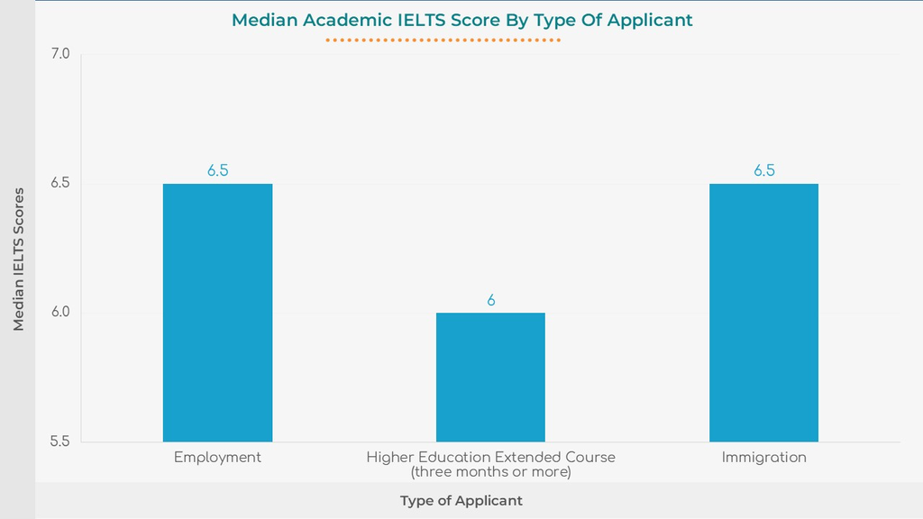

*Original chart: IELTS-Graph-1-AC-Median-Score-vs-Type-of-Applicant (Source: Sojourning Scholar)*

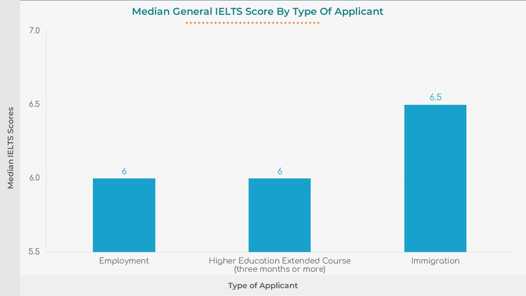

*Original chart: IELTS-Graph-2-GT-Median-Score-vs-Type-of-Applicant (Source: Sojourning Scholar)*

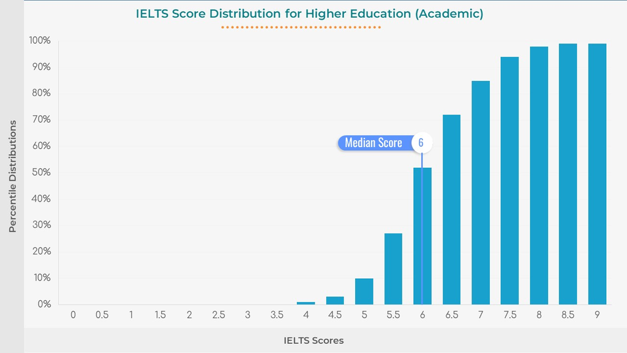

*Original chart: IELTS-Graph-3-AC-Percentile-Distribution (Source: Sojourning Scholar)*

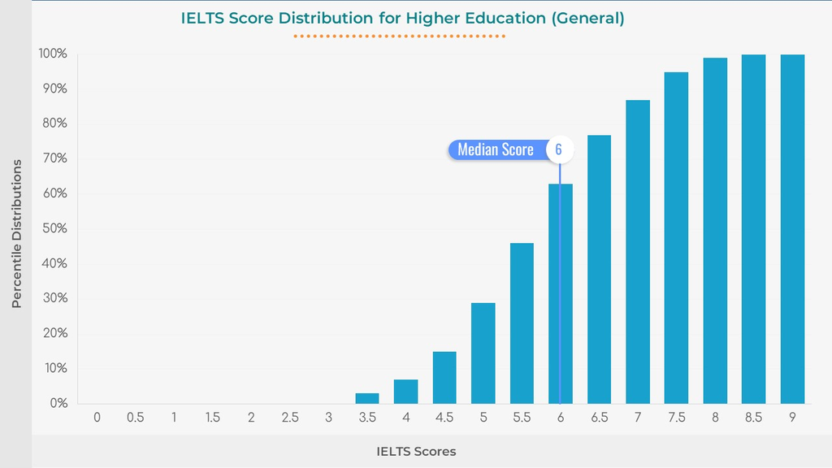

*Original chart: IELTS-Graph-4-GT-Percentile-Distribution (Source: Sojourning Scholar)*

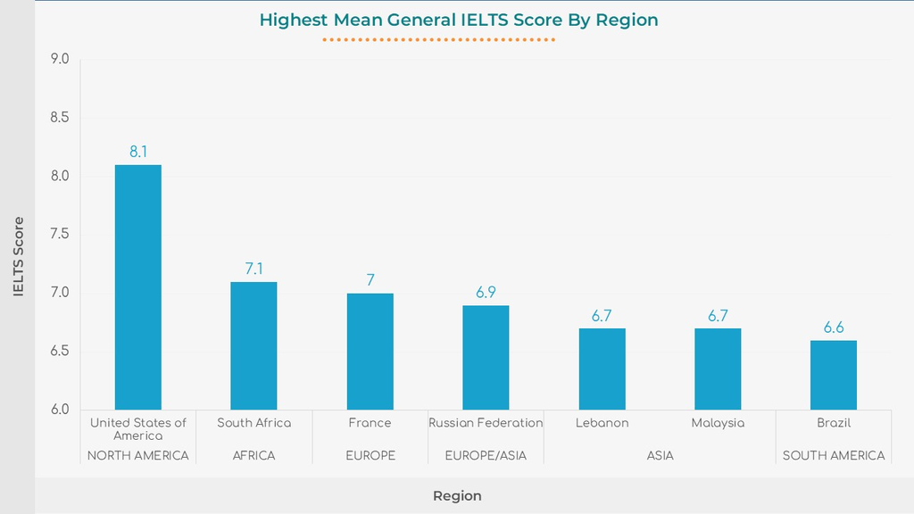

*Original chart: IELTS-Graph-6-GT-Regional-Scores (Source: Sojourning Scholar)*

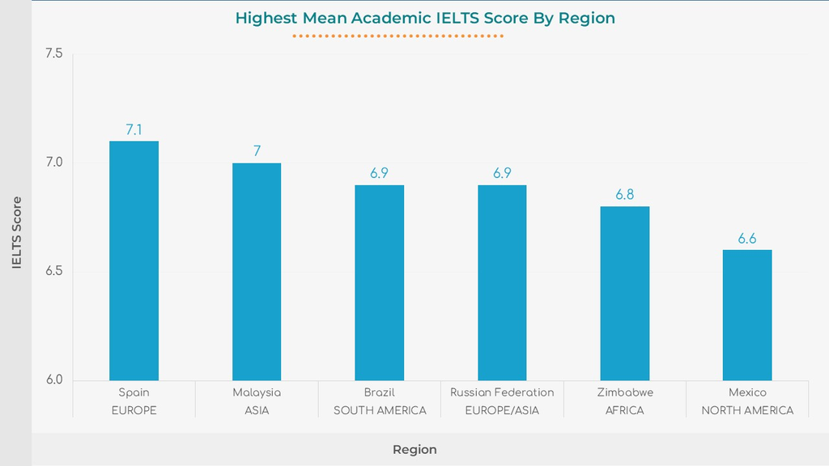

*Original chart: IELTS-Graph-7-AC-Regional-Scores (Source: Sojourning Scholar)*

# Plan to improve the data visualization

IELTS score by region

```r
demo_by_first_language <- readr::read_csv('https://raw.githubusercontent.com/rfordatascience/tidytuesday/main/data/2026/2026-08-18/demo_by_first_language.csv')
demo_by_nationality <- readr::read_csv('https://raw.githubusercontent.com/rfordatascience/tidytuesday/main/data/2026/2026-08-18/demo_by_nationality.csv')
demo_by_reasons <- readr::read_csv('https://raw.githubusercontent.com/rfordatascience/tidytuesday/main/data/2026/2026-08-18/demo_by_reasons.csv')
performance_by_first_language <- readr::read_csv('https://raw.githubusercontent.com/rfordatascience/tidytuesday/main/data/2026/2026-08-18/performance_by_first_language.csv')
performance_by_nationality <- readr::read_csv('https://raw.githubusercontent.com/rfordatascience/tidytuesday/main/data/2026/2026-08-18/performance_by_nationality.csv')
#explore the dataset
unique(demo_by_nationality[[5]])
```

```
## [1] "2024-2025" "2023-2024" "2022-2023"
```

```r
unique(demo_by_nationality[[2]])
```

```
##  [1] "Azerbaijan"                "Bangladesh"
##  [3] "Cambodia"                  "China"
##  [5] "Colombia"                  "Egypt"
##  [7] "France"                    "Germany"
##  [9] "Ghana"                     "Hong Kong"
## [11] "India"                     "Indonesia"
## [13] "Iran, Islamic Republic of" "Italy"
## [15] "Japan"                     "Jordan"
## [17] "Kazakhstan"                "Kenya"
## [19] "Korea, Republic of"        "Kuwait"
## [21] "Malaysia"                  "Mexico"
## [23] "Mongolia"                  "Myanmar"
## [25] "Nepal"                     "Nigeria"
## [27] "Oman"                      "Pakistan"
## [29] "Philippines"               "Russian Federation"
## [31] "Saudi Arabia"              "Spain"
## [33] "Sri Lanka"                 "Taiwan"
## [35] "Thailand"                  "Turkey"
## [37] "Ukraine"                   "United Arab Emirates"
## [39] "Uzbekistan"                "Vietnam"
## [41] "Algeria"                   "Argentina"
## [43] "Brazil"                    "Cameroon"
## [45] "Chile"                     "Mauritius"
## [47] "Peru"                      "South Africa"
## [49] "United States of America"  "Zimbabwe"
## [51] "Lebanon"                   "Morocco"
## [53] "Tunisia"                   "Uganda"
## [55] "Bhutan"                    "Hong Kong, SAR of China"
## [57] "Iran"                      "Qatar"
```

```r
all_country_region_map <- tibble::tribble(
  ~nationality, ~region,
  "Azerbaijan", "Central Asia & Caucasus",
  "Bangladesh", "South & Southeast Asia",
  "Cambodia", "South & Southeast Asia",
  "China", "East Asia",
  "Colombia", "Latin America",
  "Egypt", "Middle East & North Africa",
  "France", "Europe",
  "Germany", "Europe",
  "Ghana", "Sub-Saharan Africa",
  "Hong Kong", "East Asia",
  "Hong Kong, SAR of China", "East Asia",
  "India", "South & Southeast Asia",
  "Indonesia", "South & Southeast Asia",
  "Iran, Islamic Republic of", "Middle East & North Africa",
  "Iran", "Middle East & North Africa",
  "Italy", "Europe",
  "Japan", "East Asia",
  "Jordan", "Middle East & North Africa",
  "Kazakhstan", "Central Asia & Caucasus",
  "Kenya", "Sub-Saharan Africa",
  "Korea, Republic of", "East Asia",
  "Kuwait", "Middle East & North Africa",
  "Malaysia", "South & Southeast Asia",
  "Mexico", "North America",
  "Mongolia", "East Asia",
  "Myanmar", "South & Southeast Asia",
  "Nepal", "South & Southeast Asia",
  "Nigeria", "Sub-Saharan Africa",
  "Oman", "Middle East & North Africa",
  "Pakistan", "South & Southeast Asia",
  "Philippines", "South & Southeast Asia",
  "Russian Federation", "Europe",
  "Saudi Arabia", "Middle East & North Africa",
  "Spain", "Europe",
  "Sri Lanka", "South & Southeast Asia",
  "Taiwan", "East Asia",
  "Thailand", "South & Southeast Asia",
  "Turkey", "Middle East & North Africa",
  "Ukraine", "Europe",
  "United Arab Emirates", "Middle East & North Africa",
  "Uzbekistan", "Central Asia & Caucasus",
  "Vietnam", "South & Southeast Asia",
  "Algeria", "Middle East & North Africa",
  "Argentina", "Latin America",
  "Brazil", "Latin America",
  "Cameroon", "Sub-Saharan Africa",
  "Chile", "Latin America",
  "Mauritius", "Sub-Saharan Africa",
  "Peru", "Latin America",
  "South Africa", "Sub-Saharan Africa",
  "United States of America", "North America",
  "Zimbabwe", "Sub-Saharan Africa",
  "Lebanon", "Middle East & North Africa",
  "Morocco", "Middle East & North Africa",
  "Tunisia", "Middle East & North Africa",
  "Uganda", "Sub-Saharan Africa",
  "Bhutan", "South & Southeast Asia",
  "Qatar", "Middle East & North Africa"
)
```

# IELTS score by region

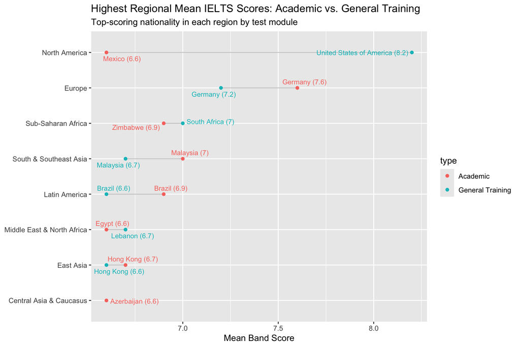

```r
leaders <- demo_by_nationality |>
  mutate(nationality = case_when(str_detect(nationality, "Hong Kong") ~ "Hong Kong",
                                 str_detect(nationality, "Iran")      ~ "Iran",
                                 TRUE ~ nationality),
         band_num = as.numeric(if_else(band == "<4", "3.5", band)),
         type     = str_replace(type, "_", " ")) |>
  group_by(type, nationality) |>
  summarize(score = round(weighted.mean(band_num, percent), 1), .groups = "drop") |>
  inner_join(distinct(all_country_region_map, nationality, region), by = "nationality") |>
  group_by(region, type) |>
  slice_max(score, n = 1, with_ties = FALSE) |>
  ungroup() |>
  mutate(region  = fct_reorder(region, score, .fun = max),
         callout = paste0(nationality, " (", score, ")"))

ggplot(leaders, aes(x = score, y = region)) +
  geom_line(aes(group = region), color = "gray80") +
  geom_point(aes(color = type)) +
  geom_text_repel(aes(label = callout, color = type), size = 3, show.legend = FALSE) +
  labs(title = "Highest Regional Mean IELTS Scores: Academic vs. General Training",
       subtitle = "Top-scoring nationality in each region by test module",
       x = "Mean Band Score", y = NULL)
```

# IELTS score by reasons

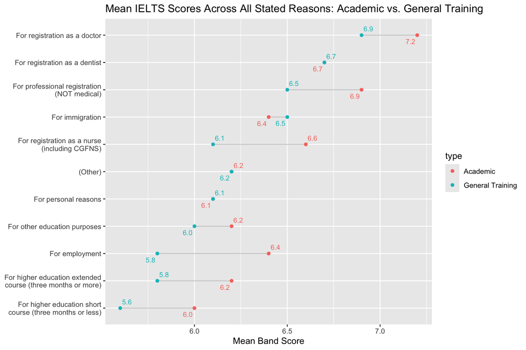

```r
reasons <- demo_by_reasons |>
  mutate(band_num = as.numeric(if_else(band == "<4", "3.5", band)),
         type     = str_replace(type, "_", " "),
         reason   = str_wrap(reason, width = 32)) |>
  group_by(reason, type) |>
  summarize(score = round(weighted.mean(band_num, percent), 1), .groups = "drop") |>
  mutate(reason = fct_reorder(reason, score))

ggplot(reasons, aes(x = score, y = reason)) +
  geom_line(aes(group = reason), color = "gray80") +
  geom_point(aes(color = type)) +
  geom_text_repel(aes(label = sprintf("%.1f", score), color = type),
                  size = 3, show.legend = FALSE) +
  labs(title = "Mean IELTS Scores Across All Stated Reasons: Academic vs. General Training",
       x = "Mean Band Score", y = NULL)
```

Similar to the logic of the graph change above, the original plot presents Academic and General Training results across separate figures and forced readers to glance back and forth. Consolidating both test types onto a shared horizontal stem for each reason applies the Law of Proximity, that places corresponding data points in immediate physical contact. This transforms what were once fragmented measurements into a unified visual comparison, allowing viewers to instantly evaluate the performance gap within each category.

# median score for higher education

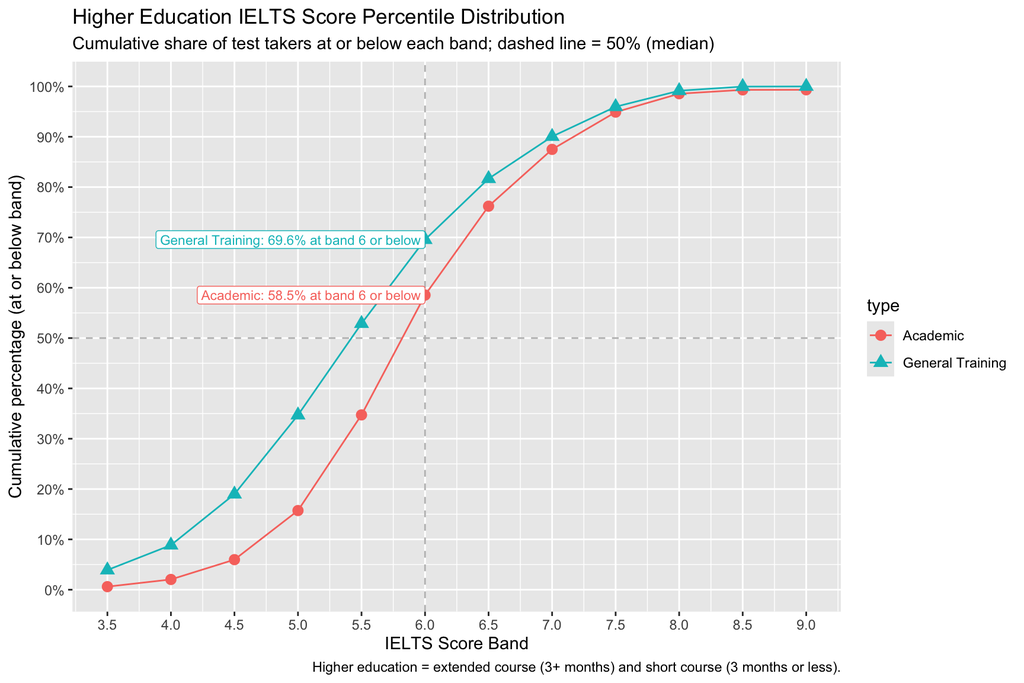

```r
cdf <- demo_by_reasons |>
  filter(str_detect(reason, "higher education")) |>
  mutate(band_num = as.numeric(if_else(band == "<4", "3.5", band)),
         type     = str_replace(type, "_", " ")) |>
  group_by(type, band_num) |>
  summarize(pct = mean(percent) * 100, .groups = "drop") |>
  group_by(type) |>
  mutate(cum_pct = cumsum(pct)) |>
  ungroup()

at_6 <- filter(cdf, band_num == 6)

ggplot(cdf, aes(x = band_num, y = cum_pct, color = type)) +
  geom_hline(yintercept = 50, linetype = "dashed", color = "gray") +
  geom_vline(xintercept = 6, linetype = "dashed", color = "gray") +
  geom_line() +
  geom_point(aes(shape = type), size = 3) +
  geom_label(data = at_6,
             aes(label = paste0(type, ": ", round(cum_pct, 1), "% at band 6 or below")),
             hjust = 1, size = 3, show.legend = FALSE) +
  scale_x_continuous(breaks = seq(3.5, 9, by = 0.5)) +
  scale_y_continuous(breaks = seq(0, 100, by = 10), labels = function(y) paste0(y, "%")) + #on't know whether there is a better way to show percentage
  labs(title = "Higher Education IELTS Score Percentile Distribution",
       subtitle = "Cumulative share of test takers at or below each band; dashed line = 50% (median)",
       caption = "Higher education = extended course (3+ months) and short course (3 months or less).",
       x = "IELTS Score Band", y = "Cumulative percentage (at or below band)")
```

Here, the original separate percentile bar charts hid the underlying cumulative S-curve and wasted nearly a third of the canvas displaying empty zero-percent categories between bands 0 and 3.0. Filtering out those empty score bands zooms the frame into the active score region, and changing solid bars into overlapping line plots applies Continuity so both cohorts can be compared together. Integrating the 50th-percentile reference line immediately reveals the true distributional spread at band 6.0, which clarifies the differences that previously appeared as identical median badges.

We also considered to make the chart more informative and able to answer the following questions listed in TidyTuesday:

- Do English speakers consistently get top marks on the English language test?
- Which parts of the test do test takers find the most difficult? Is it the same for all test takers?
- Does the reason for taking the test affect the score?
- Has there been a change in tests scores in the three years for which we have information?
1. Do English speakers consistently get top marks on the English language test?

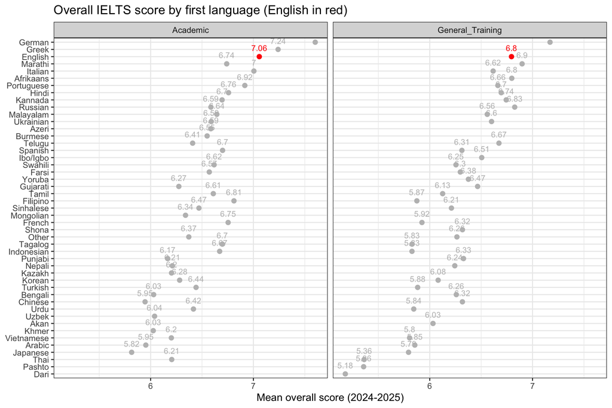

```r
base <- "https://raw.githubusercontent.com/rfordatascience/tidytuesday/main/data/2026/2026-08-18/"
perf_lang    <- read_csv(paste0(base, "performance_by_first_language.csv"))
demo_reasons <- read_csv(paste0(base, "demo_by_reasons.csv"))
perf_lang |>
  filter(part == "overall", year == "2024-2025") |>
  ggplot(aes(x = score, y = reorder(language, score), color = language == "English")) +
  geom_point(size = 2) +
  facet_wrap(~ type) +
  geom_text(aes(label = round(score, 2)), size = 3, vjust = -1) +
  scale_color_manual(values = c("gray", "red"), guide = "none") +
  labs(x = "Mean overall score (2024-2025)", y = NULL,
       title = "Overall IELTS score by first language (English in red)") +
  theme_bw()
```

English speakers score high, but they aren’t on top. In 2024–25 they ranked 3rd on Academic and 5th on General Training.

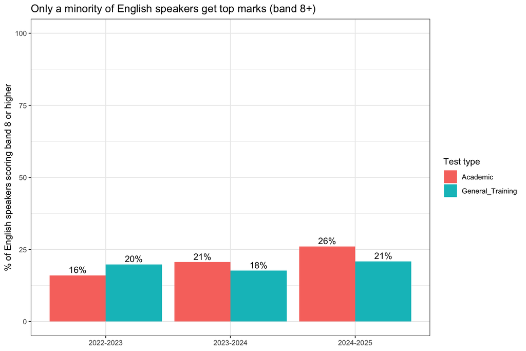

```r
demo_lang <- read_csv(paste0(base, "demo_by_first_language.csv"))

demo_lang |>
  filter(language == "English") |>
  group_by(type, year) |>
  summarize(pct_top = sum(percent[band %in% c("8", "8.5", "9")]) / sum(percent) * 100,
            .groups = "drop") |>
  ggplot(aes(x = year, y = pct_top, fill = type)) +
  geom_col(position = "dodge") +
  geom_text(aes(label = paste0(round(pct_top), "%")),
            position = position_dodge(width = 0.9), vjust = -0.4) +
  scale_y_continuous(limits = c(0, 100)) +
  labs(x = NULL, y = "% of English speakers scoring band 8 or higher", fill = "Test type",
       title = "Only a minority of English speakers get top marks (band 8+)") +
  theme_bw()
```

Among all the English speakers who took the test during 2022-2025, only 16–26% of English speakers scored band 8 or above in any year, so roughly three out of four native English speakers did not get “top marks”.

Which part is hardest? Is it the same for everyone?

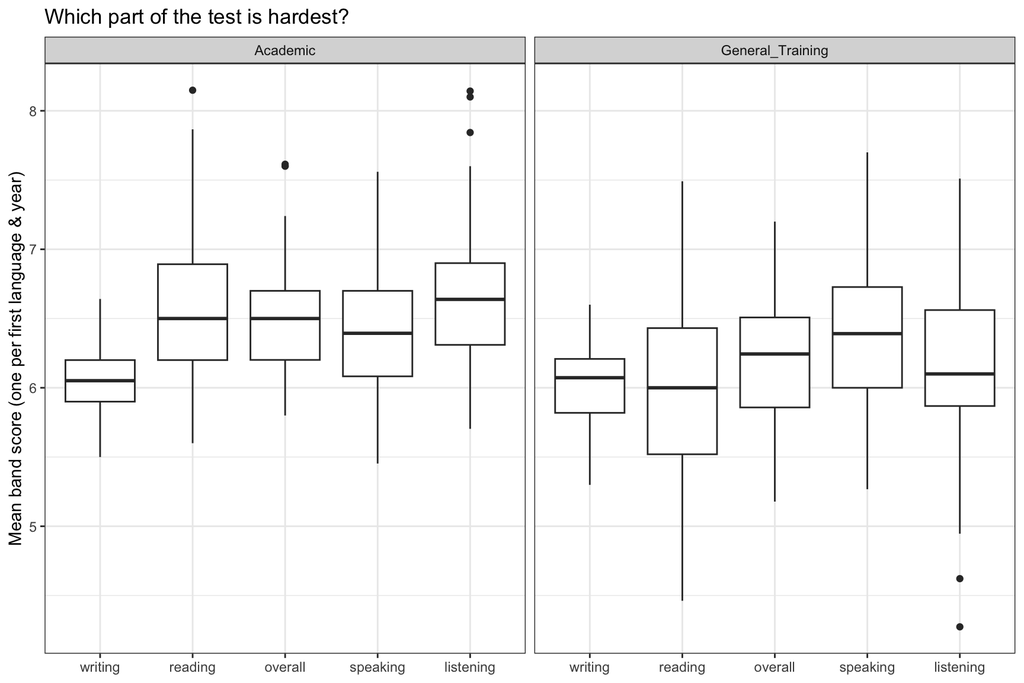

```r
perf_lang |>
  ggplot(aes(x = reorder(part, score), y = score)) +
  geom_boxplot() +
  facet_wrap(~ type) +
  labs(x = NULL, y = "Mean band score (one per first language & year)",
       title = "Which part of the test is hardest?") +
  theme_bw()
```

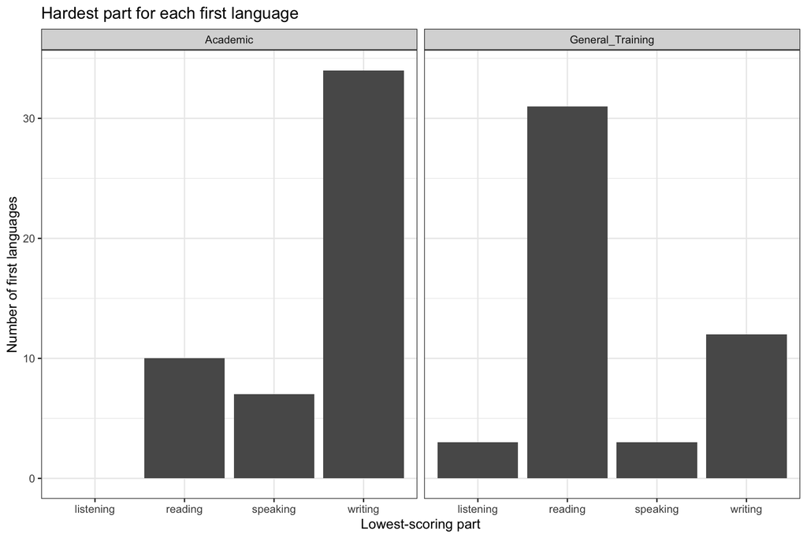

```r
# Lowest-scoring part for each first language
perf_lang |>
  group_by(type, language) |>
  slice_min(score, n = 1) |>
  ungroup() |>
  count(type, part) |>
  ggplot(aes(x = part, y = n)) +
  geom_col() +
  facet_wrap(~ type) +
  labs(x = "Lowest-scoring part", y = "Number of first languages",
       title = "Hardest part for each first language") +
  theme_bw()
```

Does the reason for taking the test affect the score?

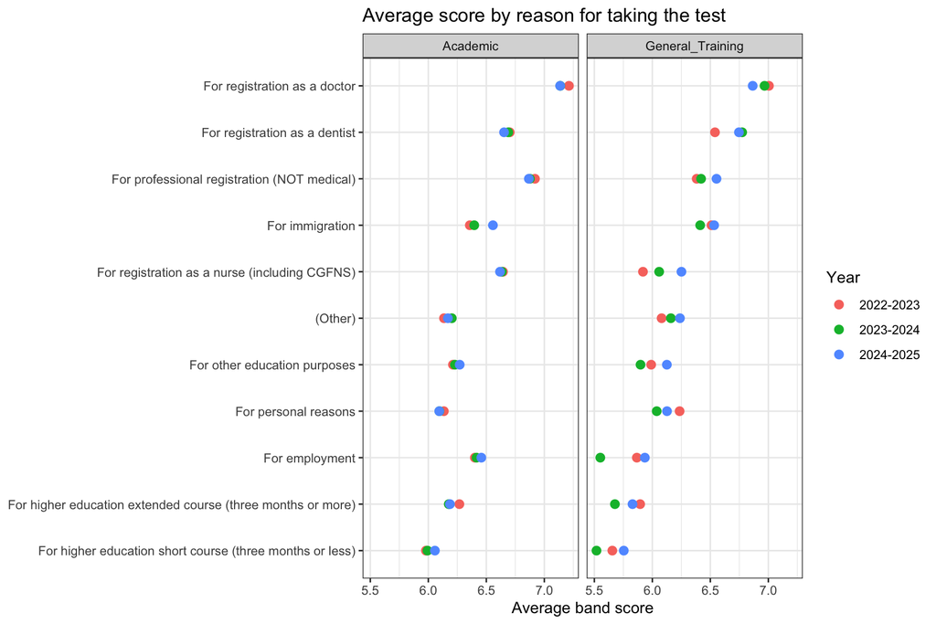

```r
demo_reasons |>
  mutate(band_num = as.numeric(if_else(band == "<4", "3.5", band))) |>
  group_by(type, reason, year) |>
  summarize(mean_band = sum(band_num * percent) / sum(percent), .groups = "drop") |>
  ggplot(aes(x = mean_band, y = reorder(reason, mean_band), color = year)) +
  geom_point(size = 2.5) +
  facet_wrap(~ type) +
  labs(x = "Average band score", y = NULL, color = "Year",
       title = "Average score by reason for taking the test") +
  theme_bw()
```

People taking the test for professional registration score highest, and people taking it for short higher-education courses score lowest. That’s a gap of about one full band.

Have scores changed over the three years?

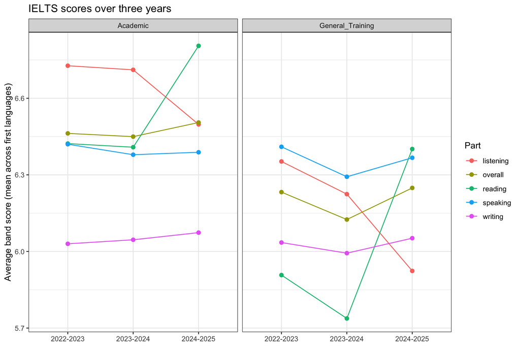

```r
perf_lang |>
  group_by(type, part, year) |>
  summarize(score = mean(score, na.rm = TRUE), .groups = "drop") |>
  ggplot(aes(x = year, y = score, color = part, group = part)) +
  geom_line() +
  geom_point(size = 2) +
  facet_wrap(~ type) +
  labs(x = NULL, y = "Average band score (mean across first languages)", color = "Part",
       title = "IELTS scores over three years") +
  theme_bw()
```

Reading score has a sharp increase in 2024-2025, while Listening fells a lot. Writing and speaking stayed almost flat. The overall score is also steady.

# A brief discussion of any major issues, snags, or hurdles you ran into and overcame during the process.

One of our challenge in improving the original visualization was merging the separate Academic and General Training charts into single views. Instead of sticking with side-by-side bar charts that competed for space, we switched to paired dot plots and overlapping curve lines, which made direct comparisons much more natural. Our main concern came from label overlap and spacing issues. Long country names, dual scores, and text tags kept running into each other or getting cut off at the edge of the image. Fixing these snags meant repeatedly nudging plot margins, tweaking axis limits, and tuning automatic label placement.

Another tricky part of this project was deciding how to visualize the data and which information was meaningful to show. The IELTS data can be cut many ways including but not limit to nationality, first language, reason for testing, test module, test part and year. For each question we had to choose one clear comparison and a chart type that suited it. Sometimes a summary statistic was misleading on its own. For example, an average score hid how few English speakers actually reached band 8, so I added a second chart showing the share at band 8 or above.